# Biofortified Varieties in target agro-ecological zones

# Introduction

The interventions associated with crop biofortification vary depending on the stage of the genetic innovation pipeline (Lung’aho 2025), from design to delivery.

The spatial components of those interventions are most visible in the product development phase, during the testing of materials, and the delivery phase, where new varieties, are released and are multiplied within the seed system.

Information on testing locations is generally sparse, but the testing regime provides information (e.g. via National Variety Trials) on the geographies for which a new biofortified crop variety is adapted. When the variety is released it can be linked to the zones for which it is adapted and mapped.

# Methods

## Extracting released variety information

Variety adaptation is one of the pieces of information contained in the Nigerian Seed Portal Initiative (Nigerian Seed Portal Initiative 2026).

The seed portal contains information about released seed Varieties, or other improved planting material. The portal has information on improved varieties of over 30 crops ( Table 1).

Table 1: # of varieties per crop

| Crop | Improved Varieties |
| --- | --- |
| Maize | 210 |
| Rice | 85 |
| Sorghum | 60 |
| Cassava | 56 |
| Cowpea | 44 |
| Yam | 31 |
| Groundnut | 29 |
| Soybean | 28 |
| Wheat | 26 |
| Tomato | 24 |
| Sugarcane | 21 |
| Pearl Millet | 19 |
| Cotton | 17 |
| Rubber, Cocoa | 14 |
| Forage Legume, Pepper , Sweet Orange | 11 |
| Potato (& Irish Potato) | 10 |
| Sweet Potato | 9 |
| Amaranthus | 8 |
| Sesame | 7 |
| Shika Grass, Barley | 6 |
| Oat, Castor, Corchorus | 5 |
| Sunflower, Solanum | 4 |
| Sokoyokoto, Coconut, Kola, Okra, Kenaf | 3 |
| Ginger, Melon, Coffee, Cabbage, Acha | 2 |

It would be time consuming to extract information about these varieties manually. Instead a script was written in R to ‘scrape’ the website and automatically extract the pertinent information.

Each ‘page’ of the seed portal contains summaries of 20 varieties and there are 41 pages.

For each variety summary the scraper extracts:

- Entry number
- Crop type
- Variety name + variety code (split from the combined field)
- Release year & registration year
- Outstanding characteristics (full text)
- Yield (extracted separately from characteristics, e.g. `10.8t/ha`)

The script loops through all 41 pages:

- Loops pages 1–41 using the URL format provided
- Polite delay of 1.5 seconds between requests `(DELAY_SECS`) — keeps you from hammering the server; adjust as needed
- Auto-retry — if a page fetch fails, it waits 3 seconds and tries once more before skipping
- Page number column added to the output so each entry can be traced to a page
- Combined output saved to a single `seedportal_varieties.csv` and `seedportal_varieties.xlsx`

Each seed variety has a separate page with more information, the detail pages contain these extra fields:

- National Code
- Original Name
- Agroecological Zones
- Origin/Source
- Developing Institute
- Breeder(s)/Collaborators
- Potential Yield (t/ha)

The links on the list pages contain both `varid` and `cropid`, so the strategy is: scrape the links from each list page, then visit each detail page.

The script is a two-stage scraper.

Stage 1 — Collect links loops all 41 list pages and harvests every `varid`= link, then remove duplicates. The detail page URL format is `variety.php?varid=XXX&cropid=YYY&task=view`.

Stage 2 — Scrape detail pages visits each link and extracts the full set of fields that only appear on the detail page:

Details of variety

| Detail | Example |
| --- | --- |
| Crop Name | Cowpea |
| National Code | NGVU-16-34 |
| Variety Name | FUAMPEA 2 |
| Original Name | UAM09 1051-1 |
| Outstanding Characteristics | Resistance to Striga… |
| Agroecological Zones | Northern Guinea and Sudan Savanna |
| Origin/Source | IAR-ABU, Zaria and IITA |
| Developing Institute | FUAM and IAR-ABU, Zaria |
| Breeder(s)/Collaborators | L.O. Omoigui, L.L. Bello… |
| Potential Yield (t/ha) | 2 (numeric) |
| Year of Release | 2016 |
| Year of Registration | 2016 |

The scraper further parses the results after scraping to assign flags depending on whether the variety characteristics include high or notable levels of micronutrients:

1. Add a new column called ‘zinc’. If the ‘outstanding characteristic’ column includes the words ‘Zinc’ or ‘Zn’ then code the zinc column as 1, otherwise 0
2. Add a new column called ‘vit_A’. If the ‘outstanding characteristic’ column includes the words ‘vitamin A’ or ‘vit A’, or ‘vit. A’ or any word containing ‘carot’ , then code the vit_A column as 1, otherwise 0.
3. Add a new column called ‘iron’. If the ‘outstanding characteristic’ column includes the words ‘Iron’ or ‘Fe’ then code the iron column as 1, otherwise 0 .
4. Add a new column called ‘n_guinea’ . If the ‘Agroecological Zones’ column includes the word ‘northern guinea’ or ‘N guinea’ or just ‘northern’ then code the ‘n_guinea’ column as 1, otherwise 0 .
5. Add a new column called ‘s_guinea’ . If the ‘Agroecological Zones’ column includes the word ‘southern guinea’ or ‘S guinea’ or just ‘southern’ then code the ‘n_guinea’ column as 1, otherwise 0 .
6. . If the ‘Agroecological Zones’ column includes the word ‘guinea’ without northern or southern then code both the ‘n_guinea’ and ‘s_guinea’ column as 1 .
7. Add a new column called ‘sudan’ . If the ‘Agroecological Zones’ column includes the word ‘sudan’ or ‘sudano’ then code the ‘sudan’ column as 1, otherwise 0 .
8. Add a new column called ‘derived’ . If the ‘Agroecological Zones’ column includes the word ‘derived’ or ‘transition’ then code the ‘derived’ column as 1, otherwise 0 .
9. Add a new column called ‘forest’ . If the ‘Agroecological Zones’ column includes the word ‘forest’ then code the ‘forest’ column as 1, otherwise 0 .
10. . If the ‘Agroecological Zones’ column includes the word ‘savanna’ or ‘savanna’ without ‘guinea’ or ‘sudan’ then code the ‘n_guinea’, ‘sudan’ and ‘s_guinea’ column as 1 .
11. Add a new column called ‘mid_alt’ . If the ‘Agroecological Zones’ column includes the word ‘mid altitude’ or ‘mid alt’ then code the ‘mid_alt’ column as 1, otherwise 0 .
12. Add a new column called ‘lowland’ . If the ‘Agroecological Zones’ column includes the word ‘lowland’ or ‘low’ then code the ‘lowland’ column as 1, otherwise 0 .
13. Add a new column called ‘sahel’ . If the ‘Agroecological Zones’ column includes the word ‘sahel’ or ‘sahelian’ then code the ‘sahel’ column as 1, otherwise 0 . In all cases ignore the case of the word and also include parts of words.
14. Add a new column called ‘all’ . If the ‘Agroecological Zones’ column includes the word ‘all’ then code the ‘all’ column as 1, otherwise 0 . In all cases ignore the case of the word and also include parts of words.

extraction logic

| Column | Logic |  |
| --- | --- | --- |
| zinc | “zinc” or “Zn” in characteristics |  |
| vit_A | “vitamin A”, “vit A”, “vit.A”, or “carot” |  |
| iron | “iron” or “Fe” |  |
| n_guinea | northern guinea / N guinea / northern / plain “guinea” / plain “savanna” |  |
| s_guinea | southern guinea / S guinea / southern / plain “guinea” / plain “savanna” |  |
| sudan | sudan / sudano / plain “savanna” |  |
| derived | “derived” or “transition” |  |
| forest | “forest” |  |
| mid_alt | “mid altitude” or “mid alt” |  |
| lowland | “lowland” or “low” |  |
| sahel | “sahel” or “sahelian” |  |
| all_zones (named all_zones to avoid conflict with R’s built-in all()) | “all” |  |

The savanna cascade (rule 10) and the bare “guinea” rule (rule 6) are handled cleanly through intermediate boolean flags before the final as.integer() conversion.

## Constructing Agro-Ecological Zones for Nigeria

There is no source of agro-ecological zones that incorporate the zones most commonly referenced and used in Nigeria i.e. the “Sahel Savanna”, “Sudan Savanna”, “Northern Guinea Savanna”, “Southern Guinea Savanna”, “Derived/Transition Savanna”, “Forest”, and “Mid-Altitude zones.

In 2015 HarvestChoice developed Agro-Ecological Zones (AEZ) for Africa South of the Sahara (SSA), based on the methodology developed by FAO and IIASA. The dataset includes three classification schemes: 5, 8, and 16 classes, referred to as the AEZ5, AEZ8, and AEZ16, respectively.

The AEZ16 scheme specifically groups regions into classes based only on climatic criteria and thresholds. There are no soil or landform criteria, in contrast to the FAO/IIASA Global Agro-Ecological Zones (GAEZ) methodology:

Climatic Characteristics

Length of Growing Period (LGP): The number of days in a year when temperature and moisture conditions are suitable for crop growth.

Thermal Regimes: Defined by temperature regimes (e.g., tropical, subtropical, temperate) that influence crop suitability.

Aridity Index: A measure of water availability, calculated as the ratio of precipitation to potential evapotranspiration. This helps distinguish between arid, semi-arid, and humid zones

The HarvestChoice dataset only has five zones for Nigeria:

- Tropic - warm / humid
- Tropic - warm / subhumid
- Tropic - cool / subhumid
- Tropic - warm / semiarid
- Tropic - warm / arid

The agro-ecological zones used in Nigeria do not map exactly onto the harvest choice zones, but they do use similar criteria (Akinwumiju et al. 2020).

For this analysis I use the following criteria and thresholds

| AEZ Name | LGP (2020) (days) | Elevation (masl)(Reuter et al. 2007) |
| --- | --- | --- |
| Sahel Savanna | <= 90 | < 800 |
| Sudan Savanna | 90 - 150 | < 800 |
| Northern Guinea Savanna | 150 - 181 | < 800 |
| Southern Guinea Savanna | 181 - 211 | < 800 |
| Derived/Transition Savanna | 211 - 270 | < 800 |
| Forest | > 270 | < 800 |
| Mid-Altitude zones |  | > 800 |

# Load the Agro-Ecological Zones

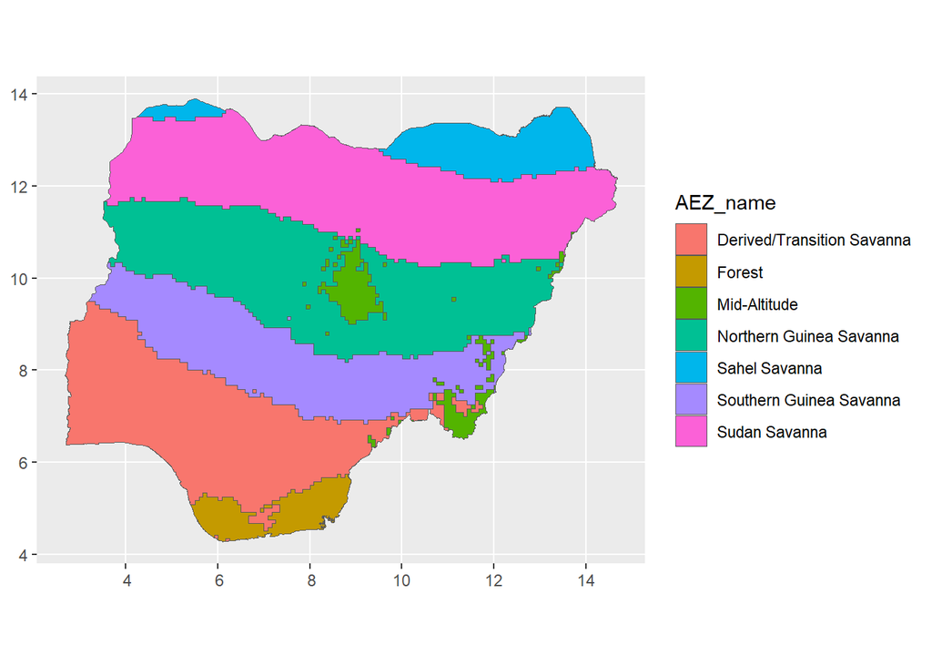

Figure 1: Nigeria Agro-ecological zones based on 2020 LGP and elevation

```r
vect_aez_geo <- vect("spatial_data/IITA_AEZ_LGP_2020_SRTM_RCL_NGA_topo.topojson")
vect_aez_geo$AEZ <- as.factor(vect_aez_geo$AEZ)
#levels(vect_aez_geo$AEZ) # Check levels
#plot(vect_aez_geo, main = "Nigeria Agro-ecological zones based on 2020 LGP and elevation", levels=TRUE)

AEZ <- 1:7
AEZ_name <- c("Sahel Savanna", "Sudan Savanna", "Northern Guinea Savanna", "Southern Guinea Savanna", "Derived/Transition Savanna", "Forest", "Mid-Altitude")

df_aez_names <- tibble(AEZ, AEZ_name)
df_aez_names$AEZ <- as.factor(df_aez_names$AEZ)
#levels(df_aez_names$AEZ) # Check levels

vect_aez_geo <- dplyr::left_join(vect_aez_geo, df_aez_names, by = c("AEZ") )

ggplot(vect_aez_geo)+
  geom_spatvector(aes(fill = AEZ_name)) +
  theme(
    plot.title = element_markdown(),
    legend.title = element_markdown(),
    axis.title = element_blank()
  )

df_aez <- as.data.frame(vect_aez_geo)
```

# Load the Variety data

## Load the Nigerian Seed Portal variety database

```r
df_nsp <- read.csv("tab_data/seedportal_varieties.csv")

# add a numeric variety id for internal use based on row number

df_nsp <- df_nsp |>
mutate(nsp_variety_id = row_number())

#str(df_nsp)
#summary(df_nsp)
```

## Filter Bio-fortified Varieties

```r
df_nsp_biofort <- dplyr::filter(df_nsp, zinc == 1 |
                                  vit_A == 1 | iron == 1)

paste("Number of Bio-fortified varieties =", nrow(df_nsp_biofort))
```

```
[1] "Number of Bio-fortified varieties = 51"
```

```r
biofort_crop_list <- as.list(unique(df_nsp_biofort$Crop.Name))


df_nsp_biofort_zinc <- dplyr::filter(df_nsp, zinc == 1)
paste("Number of varieties Bio-fortified with zinc =", nrow(df_nsp_biofort_zinc))
```

```
[1] "Number of varieties Bio-fortified with zinc = 8"
```

```r
df_nsp_biofort_crop_zinc_sum <- df_nsp_biofort_zinc |>
  group_by(Crop.Name) |>
  summarise(across(
    c(
      n_guinea,
      s_guinea,
      sudan,
      derived,
      forest,
      mid_alt,
      lowland,
      sahel,
      all_zones
    ),
    sum,
    na.rm = TRUE
  ))

df_nsp_biofort_crop_zinc_sum |>
  DT::datatable(
    rownames = F,
    caption = "Number of varieties per Crop and AEZ with notable levels of zinc",
    filter = "bottom",
    selection = list(mode = "none"),
    editable = FALSE,
    options = list(
      digits = 0,
      scrollX = TRUE,
      scrollCollapse = TRUE,
      autoWidth = TRUE,
      fixedColumns = list(leftColumns = 2),
      lengthMenu = c(15, 40),
      pageLength = 15
    ))
```

| Crop.Name | n_guinea | s_guinea | sudan | derived | forest | mid_alt | lowland | sahel | all_zones |
| --- | --- | --- | --- | --- | --- | --- | --- | --- | --- |
| Corchorus | 1 | 1 | 0 | 1 | 1 | 0 | 0 | 0 | 0 |
| Pearl Millet | 0 | 0 | 4 | 0 | 0 | 0 | 0 | 5 | 0 |
| Rice | 2 | 2 | 2 | 2 | 2 | 0 | 0 | 0 | 0 |

```r
df_nsp_biofort_iron <- dplyr::filter(df_nsp, iron == 1)
paste("Number of varieties Bio-fortified with iron =", nrow(df_nsp_biofort_iron))
```

```
[1] "Number of varieties Bio-fortified with iron = 8"
```

```r
df_nsp_biofort_crop_iron_sum  <- df_nsp_biofort_iron |>
  group_by(Crop.Name) |>
  summarise(across(
    c(
      n_guinea,
      s_guinea,
      sudan,
      derived,
      forest,
      mid_alt,
      lowland,
      sahel,
      all_zones
    ),
    sum,
    na.rm = TRUE
  ))

df_nsp_biofort_crop_iron_sum |>
  DT::datatable(
    rownames = F,
    caption = "Number of varieties per Crop and AEZ with notable levels of iron",
    filter = "bottom",
    selection = list(mode = "none"),
    editable = FALSE,
    options = list(
      digits = 0,
      scrollX = TRUE,
      scrollCollapse = TRUE,
      autoWidth = TRUE,
      fixedColumns = list(leftColumns = 2),
      lengthMenu = c(15, 40),
      pageLength = 15
    ))
```

| Crop.Name | n_guinea | s_guinea | sudan | derived | forest | mid_alt | lowland | sahel | all_zones |
| --- | --- | --- | --- | --- | --- | --- | --- | --- | --- |
| Corchorus | 1 | 1 | 0 | 1 | 1 | 0 | 0 | 0 | 0 |
| Pearl Millet | 0 | 0 | 2 | 0 | 0 | 0 | 0 | 3 | 0 |
| Sorghum | 0 | 0 | 4 | 0 | 0 | 0 | 0 | 3 | 0 |

```r
df_nsp_biofort_vit_A <- dplyr::filter(df_nsp, vit_A == 1)
paste("Number of varieties Bio-fortified with vitamin A =", nrow(df_nsp_biofort_vit_A))
```

```
[1] "Number of varieties Bio-fortified with vitamin A = 39"
```

```r
df_nsp_biofort_crop_vit_A_sum <- df_nsp_biofort_vit_A |>
  group_by(Crop.Name) |>
  summarise(across(
    c(
      n_guinea,
      s_guinea,
      sudan,
      derived,
      forest,
      mid_alt,
      lowland,
      sahel,
      all_zones
    ),
    sum,
    na.rm = TRUE
  ))

df_nsp_biofort_crop_vit_A_sum |>
  DT::datatable(
    rownames = F,
    caption = "Number of varieties per Crop and AEZ with notable levels of pro Vitamin A",
    filter = "bottom",
    selection = list(mode = "none"),
    editable = FALSE,
    options = list(
      digits = 0,
      scrollX = TRUE,
      scrollCollapse = TRUE,
      autoWidth = TRUE,
      fixedColumns = list(leftColumns = 2),
      lengthMenu = c(15, 40),
      pageLength = 15
    ))
```

| Crop.Name | n_guinea | s_guinea | sudan | derived | forest | mid_alt | lowland | sahel | all_zones |
| --- | --- | --- | --- | --- | --- | --- | --- | --- | --- |
| Cassava | 3 | 9 | 1 | 7 | 8 | 0 | 0 | 0 | 0 |
| Maize | 16 | 15 | 5 | 7 | 5 | 0 | 0 | 0 | 0 |
| Sorghum | 0 | 1 | 0 | 0 | 0 | 0 | 0 | 0 | 0 |
| Sunflower | 2 | 2 | 2 | 2 | 0 | 0 | 0 | 0 | 0 |
| Sweet Potato | 3 | 2 | 2 | 2 | 2 | 0 | 0 | 0 | 0 |

## Load the HarvestPlus database of biofortified crops

An alternative source of information on biofortified crops released in Nigeria is the HarvestPlus database of Biofortified Crops Released (https://bcr.harvestplus.org/varieties_released_list#).

```r
df_hp <- read.csv("tab_data/hp_ListofCrops.csv")

# add a numeric variety id for internal use based on row number

df_hp <- df_hp |>
mutate(hp_variety_id = row_number())
```

## Filter Varieties in Nigeria

There are 498 varieties in the database (as of 29/09/2026), but this is a global list, so we need to filter and extract only those varieties released in Nigeria.

```r
df_hp_ng <- dplyr::filter(df_hp, Country == "Nigeria")

paste("Number of Bio-fortified varieties in Nigeria =", nrow(df_hp_ng))
```

```
[1] "Number of Bio-fortified varieties in Nigeria = 31"
```

```r
hp_biofort_crop_list_ng <- as.list(unique(df_hp_ng$Biofortified_crop_name))

df_hp_ng_count <- df_hp_ng |>
  group_by(Biofortified_crop_name) |>
  summarise(num_vars = n())

df_hp_ng_count |>
  DT::datatable(
    rownames = F,
    colnames=c("Crop", "Number of varieties"),
    caption = "Number of biofortified varieties per Crop in Nigeria in the HP database",
    filter = "bottom",
    selection = list(mode = "none"),
    editable = FALSE,
    options = list(
      digits = 0,
      scrollX = TRUE,
      scrollCollapse = TRUE,
      #autoWidth = TRUE,
      fixedColumns = list(leftColumns = 2),
      lengthMenu = c(10, 20),
      pageLength = 10
    ))
```

Table 2

| Crop | Number of varieties |
| --- | --- |
| Iron Pearl Millet | 1 |
| Vitamin A Cassava | 9 |
| Vitamin A Maize | 16 |
| Vitamin A Sweet Potato | 3 |
| Zinc Rice | 2 |

The HarvestPlus database has less information about the varieties than the Nigerian Seed Portal, but in many cases it does include the micronutrient concentration.

It is therefore worthwhile attempting to merge the two databases.

## Load GLOMIP database

The Global Market Intelligence Platform includes a Product Catalog and downloadable database ( https://glomip.cgiar.org/product-catalog ).

As of October 2026 the database is limited to Rice, and the database does not say where varieties have been released, rather their ‘Country of Origin’.

```r
df_glomip <- read.csv("tab_data/Product Catalog GloMIP.csv")
```

The other variables in the database include references to market segments (which have their own database), but the information in the downloadable variety catalogue is less extensive than the information which appears in the website for each variety, such as the “full description”, “key strengths” and “variety performance”.

An example where such a link does exist is for rice varieties in the GloMIP product catalogue (Table 3). This allows a variety to be linked to specific traits which have units, and thresholds.

Table 3: # Example of links between variety, Market Segment and Target Product Profile

| Variety_name | MS_short | TPP (from MS) | Trait ID | Trait Type | Trait Name |
| --- | --- | --- | --- | --- | --- |
| Binadhan-7 | Rice Indica SA MS00299 | Rice Indica SA IRRI TPP00262 | TR-00174 | Abiotic Yield Under Late Stage Drought |  |
|  |  |  | TR-00176 | Quality - Analytical | Head Rice Recovery |
|  |  |  | TR-00164 | Quality - Analytical | Amylose Content |
|  |  |  | TR-00165 | Quality - Visual | Chalkiness |
|  |  |  | TR-00172 | Agronomic | Yield |
|  |  |  | TR-00180 | Morphological | Plant Height |
|  |  |  | TR-00181 | Biotic - Disease | Bacterial Leaf Blight |
|  |  |  | TR-00183 | Biotic - Disease | Leaf Blast |
|  |  |  | TR-00184 | Biotic - Disease | Neck Blast |
|  |  |  | TR-00185 | Biotic - Disease | Brown Spot |
|  |  |  | TR-00187 | Biotic - Disease | Sheath Blight |
|  |  |  | TR-00188 | Biotic - Disease | Sheath Rot |
|  |  |  | TR-00192 | Biotic - Pests | Brown Plant Hopper |
|  |  |  | TR-00175 | Abiotic | Heat Tolerance |

Another example is for Maize, where the market segment and Target Product Profile can be linked, this segment and product profile is particularly relevant because one of the essential traits to improve is the Provitamin A Carotenoid content (Table 4). However, from the information available there is no way to link the market segment to a released variety.

Table 4: # Example of links between Market Segment and Target Product Profile but without a variety

| Variety_name | MS_short | TPP (from MS) | Trait ID | Trait Type | Trait Name |
| --- | --- | --- | --- | --- | --- |
|  | Maize WAF MS00861 | Maize WAF IITA TPP00220 | TR-00120 | Quality - Analytical | Provitamin A Carotenoid Content |

The biggest issue for linking the GloMIP databases to the varieties in the HarvestPlus and Nigerian Seed Portal is the lack of a reference to a Market Segment in those databases. As a consequence it is currently not possible to incorporate the information in the GloMIP data base with the varieties in the NSP and HP databases.

# Merge variety databases

To merge the databases it is necessary to find variables that are common to both the HarvestPlus and the Nigerian Seed Portal databases.

```r
as.data.frame(colnames(df_nsp)) |>
    DT::datatable(
    rownames = F,
    caption = "NSP database variables",
    filter = "bottom",
    selection = list(mode = "none"),
    editable = FALSE,
    options = list(
      digits = 0,
      scrollX = TRUE,
      scrollCollapse = TRUE,
      #autoWidth = TRUE,
      fixedColumns = list(leftColumns = 2),
      lengthMenu = c(10, 20),
      pageLength = 20
    ))
as.data.frame(colnames(df_hp)) |>
    DT::datatable(
    rownames = F,
    caption = "HP database variables",
    filter = "bottom",
    selection = list(mode = "none"),
    editable = FALSE,
    options = list(
      digits = 0,
      scrollX = TRUE,
      scrollCollapse = TRUE,
      #autoWidth = TRUE,
      fixedColumns = list(leftColumns = 2),
      lengthMenu = c(10, 20),
      pageLength = 20
    ))
```

Table 5: Two tables

(a) Nigerian Seed Portal

| colnames(df_nsp) |
| --- |
| detail_url |
| Crop.Name |
| National.Code |
| Variety.Name |
| Original.Name |
| Origin.Source |
| Developing.Institute |
| Breeder.s..Collaborators |
| Potential.Yield..t.ha. |
| Year.of.Release |

[output cut: 30 more lines]

(b) HarvestPlus

| colnames(df_hp) |
| --- |
| Biofortified_crop_name |
| Country |
| Region_Continent |
| Variety_Name |
| Other_or_Local_name |
| Year_Released |
| Micronutrient_concentratio |
| Yield |
| hp_variety_id |

From (Table 5) it is clear that some of the variables are common, but care will need to be taken in how the records are matched.

Common Variables in Nigerian Seed Portal (NSP) and HarvestPlus (HP) databases

| NSP | HP | Comments |
| --- | --- | --- |
| `Crop.Name` | `Biofortified_crop_name` | would require extraction of crop name from HP |
| `Variety.Name` | `Variety_Name` |  |
| `Variety.Name` | `Other_or_Local_name` | to account for differences in variety name |
| `Original.Name` | `Other_or_Local_name` |  |
| `Original.Name` | `Variety_Name` | to account for differences in variety name |
| `Year.of.Release` | `Year_Released` |  |
| `oc` | `Micronutrient_concentratio` | would require extraction of micronutrient concentrations from `oc` variable in NSP |
| `Summary.Yield..t.ha.` | `Yield` | NSP has two values for yield |
| `Potential.Yield..t.ha.` | `Yield` | NSP has two values for yield |
| `zinc` | `Biofortified_crop_name` | previously extracted from `oc` variable in NSP |
| `vit_A` | `Biofortified_crop_name` | previously extracted from `oc` variable in NSP |
| `iron` | `Biofortified_crop_name` | previously extracted from `oc` variable in NSP |

## Merge by variety name

The varieties which are matched are exclusively Vitamin A rich Cassava and Maize varieties.

```r
df_merge_varname <- inner_join(df_nsp_biofort, df_hp_ng, by = c("Variety.Name" = "Variety_Name"))

df_merge_varname |> select(Crop.Name, Biofortified_crop_name, Variety.Name, Year.of.Release, Year_Released ) |>
  arrange(is.na(Biofortified_crop_name), desc(Crop.Name)) |>
  DT::datatable(
    rownames = F,
    colnames=c("Crop Name (NSP)", "Crop Name (HP)" , "Variety Name", "Year Released (NSP)", "Year Released (HP)"),
    caption = "Merge by variety name",
    filter = "bottom",
    selection = list(mode = "none"),
    editable = FALSE,
    options = list(
      #order = list(list(0, 'desc'), list(1, 'desc')),
      digits = 0,
      scrollX = TRUE,
      scrollCollapse = TRUE,
      #autoWidth = TRUE,
      fixedColumns = list(leftColumns = 2),
      lengthMenu = c(10, 20),
      pageLength = 20
    ))
```

Table 6

| Crop Name (NSP) | Crop Name (HP) | Variety Name | Year Released (NSP) | Year Released (HP) |
| --- | --- | --- | --- | --- |
| Maize | Vitamin A Maize | Oba Super 8 | 2023 | 2023 |
| Maize | Vitamin A Maize | SAMMAZ 67 | 2022 | 2022 |
| Maize | Vitamin A Maize | WAC58PVEE | 2022 | 2022 |
| Maize | Vitamin A Maize | SAMMAZ 59 | 2020 | 2020 |
| Maize | Vitamin A Maize | SAMMAZ 60 | 2020 | 2020 |
| Maize | Vitamin A Maize | SAMMAZ 52 | 2017 | 2017 |
| Maize | Vitamin A Maize | SAMMAZ 49 | 2016 | 2016 |
| Maize | Vitamin A Maize | SAMMAZ 43 | 2015 | 2015 |
| Maize | Vitamin A Maize | SAMMAZ 44 | 2015 | 2015 |
| Maize | Vitamin A Maize | SAMMAZ 38 | 2013 | 2013 |

[output cut: 7 more lines]

Even when the full databases are merged - HP for all countries, and NSP for biofort and non-biofort varieties - the situation does not improve, and indeed a Sweet Potato variety from Madagascar called “Gloria” is matched with the Nigerian Cabbage variety of the same name.

```r
df_merge_full_varname <- inner_join(df_nsp, df_hp, by = c("Variety.Name" = "Variety_Name"))
```

Some variety names are very similar, but differ due to extra or missing spaces, dashes etc. between the text. Other examples are where a variety name in either of the databases has an extra name added.

We can simplify the variety names and join using a cleaned key variable. This increases the number of matches to 23, and now includes Iron biofortified Pearl Millet and Zinc Rice varieties.

By matching the full name from one database with a partial match in the other we capture an additional three records, giving 26 matches.

```r
# Helper to normalize whitespace
clean_key <- function(x) {
  x |>
    str_replace_all("[^\\p{L}\\p{N}]+", "") |>  # keep only letters and digits (any language)
    str_to_lower()
}

add_segments <- function(df, col) {
  df |>
    mutate(
      .id = row_number(),
      segment = map(.data[[col]], \(x) c(x, str_split_1(x, "[()/\\[\\]]")))  # full value + each piece
    ) |>
    unnest(segment) |>
    mutate(key = clean_key(segment)) |>
    filter(key != "") |>
    distinct(.id, key, .keep_all = TRUE)
}

df_segmented_nsp <- add_segments(df_nsp_biofort, "Variety.Name")
df_segmented_hp <- add_segments(df_hp_ng, "Variety_Name")

df_matches_regex <- inner_join(
  df_segmented_nsp |> select(.id1 = .id, key),
  df_segmented_hp |> select(.id2 = .id, key),
  by = "key",
  relationship = "many-to-many"
) |>
  distinct(.id1, .id2)   # one row per matching record pair

df_merge_varname_clean <- df_matches_regex |>
  left_join(df_nsp_biofort |> mutate(.id1 = row_number()), by = ".id1") |>
  left_join(df_hp_ng |> mutate(.id2 = row_number()), by = ".id2", suffix = c("_nsp", "_hp")) |>
  select(-.id1, -.id2)

#
#
# df_nsp_biofort_clean <- df_nsp_biofort |> mutate(Variety_Name_clean = clean_key(Variety.Name))
# df_hp_ng_clean <- df_hp_ng |> mutate(Variety_Name_clean = clean_key(Variety_Name))
#
#
# df_merge_varname_clean <- inner_join(df_nsp_biofort_clean, df_hp_ng_clean, by = "Variety_Name_clean")

df_merge_varname_clean |> select(Crop.Name, Biofortified_crop_name, Variety_Name, Variety.Name, Year.of.Release, Year_Released ) |>
  arrange(is.na(Biofortified_crop_name), desc(Crop.Name)) |>
  DT::datatable(
    rownames = F,
    colnames=c("Crop Name (NSP)", "Crop Name (HP)" , "Variety Name (NSP)", "Variety Name (HP)", "Year Released (NSP)", "Year Released (HP)"),
    caption = "Merge by variety name",
    filter = "bottom",
    selection = list(mode = "none"),
    editable = FALSE,
    options = list(
      #order = list(list(0, 'desc'), list(1, 'desc')),
      digits = 0,
      scrollX = TRUE,
      scrollCollapse = TRUE,
      #autoWidth = TRUE,
      fixedColumns = list(leftColumns = 2),
      lengthMenu = c(10, 20),
      pageLength = 20
    ))
```

Table 8

| Crop Name (NSP) | Crop Name (HP) | Variety Name (NSP) | Variety Name (HP) | Year Released (NSP) | Year Released (HP) |
| --- | --- | --- | --- | --- | --- |
| Rice | Zinc Rice | Faro71 | FARO 71 | 2025 | 2025 |
| Rice | Zinc Rice | Faro72 | FARO 72 | 2025 | 2025 |
| Pearl Millet | Iron Pearl Millet | LCIC MV5 | LCICMV-5 | 2023 | 2023 |
| Maize | Vitamin A Maize | Oba Super 8 | Oba Super 8 | 2023 | 2023 |
| Maize | Vitamin A Maize | HAKIMI 1 | HAKIMI 1 | 2022 | 2022 |
| Maize | Vitamin A Maize | SAMMAZ 67 | SAMMAZ 67 | 2022 | 2022 |
| Maize | Vitamin A Maize | WAC58PVEE | WAC58PVEE | 2022 | 2022 |
| Maize | Vitamin A Maize | WAC42PVEE | WAC 42PVEE | 2022 | 2022 |
| Maize | Vitamin A Maize | SAMLAK 1608 LY | SAMLAK 1608LY | 2022 | 2022 |
| Maize | Vitamin A Maize | SAMMAZ 59 | SAMMAZ 59 | 2020 | 2020 |

[output cut: 16 more lines]

If we use the alternative names in both databases it appears we are able to match a further three varieties (Table 9). However, on closer inspection those extra three records are actually cassava varieties which have ambiguous or contradictory name combinations:

| Variety Name (NSP) | Variety Name (HP) | Alternative Name (NSP) | Alternative Name (HP) | Year Released (NSP) | Year Released (HP) |
| --- | --- | --- | --- | --- | --- |
| UMUCASS 54 (NO- HUNGER) | UMUCASS 53 | IBA164773 | IBA164773 | 2022 | 2022 |
| UMUCASS 54 (NO- HUNGER) | UMUCASS 54 | IBA164773 | IBA164773 | 2022 | 2022 |
| UMUCASS 45 | UMUCASS 46 | IITA TMS I 07/0593 | IITA TMS I 07/0593 | 2014 | 2014 |

In these cases the alternative names from each database match, but only the second record in the table is a true match, while records 1 and 3 would need investigation to see why the alternative names match, perhaps due to the pedigree of the varieties.

```r
segment_keys <- function(df, col) {
  df |>
    mutate(.id = row_number()) |>                      # assign IDs BEFORE filtering so they match df_id later
    filter(!is.na(.data[[col]])) |>                    # drop NAs so str_split_1() never sees one
    mutate(
      segment = map(.data[[col]], \(x) c(x, str_split_1(x, "[()/\\[\\]]")))
    ) |>
    unnest(segment) |>
    mutate(key = clean_key(segment)) |>
    filter(key != "") |>
    distinct(.id, key)
}


# Keys from several columns, labelled by source column
segment_keys_multi <- function(df, cols) {
  map(cols, \(col) segment_keys(df, col) |> mutate(col = col)) |>
    list_rbind()
}

df_nsp_keys <- segment_keys_multi(df_nsp_biofort, c("Variety.Name", "Original.Name"))
df_hp_keys <- segment_keys_multi(df_hp_ng, c("Variety_Name", "Other_or_Local_name"))

# Check the keys
# Every record should appear with a sensible number of keys
df_nsp_keys |> count(col)                       # keys per source column
```

```
# A tibble: 2 × 2
  col               n
  <chr>         <int>
1 Original.Name    68
2 Variety.Name     59
```

```r
df_nsp_keys |> summarise(records = n_distinct(.id))
```

```
# A tibble: 1 × 1
  records
    <int>
1      51
```

```r
df_hp_keys |> count(col)                       # keys per source column
```

```
# A tibble: 2 × 2
  col                     n
  <chr>               <int>
1 Other_or_Local_name    36
2 Variety_Name           30
```

```r
df_hp_keys |> summarise(records = n_distinct(.id))
```

```
# A tibble: 1 × 1
  records
    <int>
1      31
```

```r
# Records that produced no keys at all (both columns NA or punctuation-only)
df_nsp_biofort |> mutate(.id = row_number()) |> anti_join(df_nsp_keys, by = ".id")
```

```
 [1] detail_url               Crop.Name                National.Code
 [4] Variety.Name             Original.Name            Origin.Source
 [7] Developing.Institute     Breeder.s..Collaborators Potential.Yield..t.ha.
[10] Year.of.Release          Year.of.Registration     Summary.Yield..t.ha.
[13] oc                       agro                     zinc
[16] vit_A                    iron                     zinc_content
[19] iron_content             vitA_content             .has_n_guinea
[22] .has_s_guinea            .has_guinea              .has_savanna
[25] .has_sudan               .has_derived             .has_forest
[28] .guinea_only             .savanna_only            .implied_derived
[31] n_guinea                 s_guinea                 sudan
[34] derived                  forest                   mid_alt
[37] lowland                  sahel                    all_zones
[40] nsp_variety_id           .id
<0 rows> (or 0-length row.names)
```

```r
# Records that produced no keys at all (both columns NA or punctuation-only)
df_hp_ng |> mutate(.id = row_number()) |> anti_join(df_hp_keys, by = ".id")
```

```
 [1] Biofortified_crop_name     Country
 [3] Region_Continent           Variety_Name
 [5] Other_or_Local_name        Year_Released
 [7] Micronutrient_concentratio Yield
 [9] hp_variety_id              .id
<0 rows> (or 0-length row.names)
```

```r
df_matches_multi <- inner_join(
  df_nsp_keys |> rename(.id1 = .id, nsp_col = col),
  df_hp_keys |> rename(.id2 = .id, hp_col = col),
  by = "key",
  relationship = "many-to-many"
)

# One row per matching record pair
df_matches <- df_matches_multi |> distinct(.id1, .id2)

df_match_summary <- df_matches_multi |>
  group_by(.id1, .id2) |>
  summarise(
    matched_on = paste(unique(paste(nsp_col, hp_col, sep = " -> ")), collapse = "; "),
    n_col_pairs = n_distinct(paste(nsp_col, hp_col)),
    .groups = "drop"
  )

df_nsp_biofort_id <- df_nsp_biofort |> mutate(.id1 = row_number())
df_hp_ng_id <- df_hp_ng |> mutate(.id2 = row_number())

df_merge_multi <- df_match_summary |>
  inner_join(df_nsp_biofort_id, by = ".id1") |>
  inner_join(df_hp_ng_id, by = ".id2", suffix = c("_nsp", "_hp")) |>
  select(-.id1, -.id2)

df_unmatched_nsp <- df_nsp_biofort_id |> anti_join(df_matches, by = ".id1")
df_unmatched_hp <- df_hp_ng_id |> anti_join(df_matches, by = ".id2")

df_merge_multi |> select(Crop.Name, Biofortified_crop_name, Variety.Name, Variety_Name, Original.Name, Other_or_Local_name, Year.of.Release, Year_Released ) |>
  arrange(is.na(Biofortified_crop_name), desc(Crop.Name)) |>
  DT::datatable(
    rownames = F,
    colnames=c("Crop Name (NSP)", "Crop Name (HP)" , "Variety Name (NSP)", "Variety Name (HP)", "Alternative Name (NSP)", "Alternative Name (HP)", "Year Released (NSP)", "Year Released (HP)"),
    caption = "Merge by variety name and alternative name",
    filter = "bottom",
    selection = list(mode = "none"),
    editable = FALSE,
    options = list(
      #order = list(list(0, 'desc'), list(1, 'desc')),
      digits = 0,
      scrollX = TRUE,
      scrollCollapse = TRUE,
      #autoWidth = TRUE,
      fixedColumns = list(leftColumns = 2),
      lengthMenu = c(10, 20),
      pageLength = 20
    ))
```

Table 9

| Crop Name (NSP) | Crop Name (HP) | Variety Name (NSP) | Variety Name (HP) | Alternative Name (NSP) | Alternative Name (HP) | Year Released (NSP) | Year Released (HP) |
| --- | --- | --- | --- | --- | --- | --- | --- |
| Rice | Zinc Rice | FARO 71 | Faro71 | BRRI DHAN 74 | BRRI DHAN 74 | 2025 | 2025 |
| Rice | Zinc Rice | FARO 72 | Faro72 | BRRI DHAN 100 | BRRI DHAN 100 | 2025 | 2025 |
| Pearl Millet | Iron Pearl Millet | LCICMV-5 | LCIC MV5 | Chakti | Chakti | 2023 | 2023 |
| Maize | Vitamin A Maize | Oba Super 8 | Oba Super 8 | EEPVAH-68 | EEPVAH-68 | 2023 | 2023 |
| Maize | Vitamin A Maize | HAKIMI 1 | HAKIMI 1 | LY1606 | LY1606 | 2022 | 2022 |
| Maize | Vitamin A Maize | SAMMAZ 67 | SAMMAZ 67 | A1820-4 | A1820-4 | 2022 | 2022 |
| Maize | Vitamin A Maize | WAC58PVEE | WAC58PVEE | EEPVAH-58 | EEPVAH-58 | 2022 | 2022 |
| Maize | Vitamin A Maize | WAC 42PVEE | WAC42PVEE | EEPVAH-42 | EEPVAH-42 | 2022 | 2022 |
| Maize | Vitamin A Maize | SAMLAK 1608LY | SAMLAK 1608 LY | LY1608 | LY1608 | 2022 | 2022 |
| Maize | Vitamin A Maize | SAMMAZ 59 | SAMMAZ 59 | F2SCA1413-36 | F2SCA1413-36 | 2020 | 2020 |

[output cut: 19 more lines]

When we review the unmatched records from both databases, and show alternative names for the varieties, we can see if there are any other possible matches (Table 10).

Potential matches are for two hybrid maize varieties which have similar names but not exact matches. There are no sweet potato varieties that are common in the databases, “UMUSPO/4 Solo-Gold” in the NSP database almost matches two entries in the HarvestPlus database: “Solo Gold”, and “UMUSPO 4” (as an alternative name to a different entry).

These kind of matches can only really be made manually.

```r
df_nsp_biofort_id <- df_nsp_biofort |> mutate(.id1 = row_number())
df_hp_ng_id <- df_hp_ng |> mutate(.id2 = row_number())

# Records in df1 with no match in df2
df_unmatched_nsp <- df_nsp_biofort_id |> anti_join(df_matches, by = ".id1")

# Records in df2 with no match in df1
df_unmatched_hp <- df_hp_ng_id |> anti_join(df_matches, by = ".id2")


df_unmatched_nsp |> select(.id1, Crop.Name, Variety.Name, National.Code, Year.of.Release) |>
  DT::datatable(
    rownames = F,
    colnames=c( "NSP ID", "Crop Name", "Variety Name", "National Code", "Year Released"),
    caption = "NSP varieties without a match",
    filter = "bottom",
    selection = list(mode = "none"),
    editable = FALSE,
    options = list(
      order = list(list(0, 'desc'), list(1, 'desc')),
      digits = 0,
      scrollX = TRUE,
      scrollCollapse = TRUE,
      #autoWidth = TRUE,
      fixedColumns = list(leftColumns = 2),
      lengthMenu = c(10, 20),
      pageLength = 20
    ))
df_unmatched_hp |> select(.id2, Biofortified_crop_name, Variety_Name, Other_or_Local_name, Year_Released) |>
  DT::datatable(
    rownames = F,
    colnames=c("HP ID", "Crop Name", "Variety Name", "Other or Local Name", "Year Released"),
    caption = "HP varieties without a match",
    filter = "bottom",
    selection = list(mode = "none"),
    editable = FALSE,
    options = list(
      order = list(list(0, 'desc'), list(1, 'desc')),
      digits = 0,
      scrollX = TRUE,
      scrollCollapse = TRUE,
      #autoWidth = TRUE,
      fixedColumns = list(leftColumns = 2),
      lengthMenu = c(10, 20),
      pageLength = 20
    ))
```

Table 10: Two tables

(a) Nigerian Seed Portal

| NSP ID | Crop Name | Variety Name | National Code | Year Released |
| --- | --- | --- | --- | --- |
| 1 | Pearl Millet | LCIC MH2 | NGPG-25-16 | 2025 |
| 2 | Pearl Millet | LCIC MH3 | NGPG-25-17 | 2025 |
| 3 | Pearl Millet | LCIC MH4 | NGPG-25-18 | 2025 |
| 4 | Pearl Millet | LCIC MH5 | NGPG-25-19 | 2025 |
| 7 | Maize | SAMMAZ 70 | NGZM-24-191 | 2024 |
| 8 | Corchorus | HORTICOR 1 | NGCO-24-4 | 2024 |
| 11 | Sorghum | SAMSORG 52 | NGSB-23-57 | 2023 |
| 12 | Sorghum | SAMSORG 53 | NGSB-23-58 | 2023 |
| 23 | Maize | SAMMAZ 57 | NGZM-19-148 | 2019 |
| 24 | Sweet Potato | UMUSPO/4 Solo-Gold | NGIB-18-9 | 2018 |

[output cut: 15 more lines]

(b) HarvestPlus

| HP ID | Crop Name | Variety Name | Other or Local Name | Year Released |
| --- | --- | --- | --- | --- |
| 1 | Vitamin A Sweet Potato | - | UMUSPO 4 | 2013 |
| 2 | Vitamin A Sweet Potato | King J |  | 2012 |
| 3 | Vitamin A Sweet Potato | Solo Gold |  | 2018 |
| 8 | Vitamin A Maize | Ife Hyb 3 | SC510 | 2012 |
| 9 | Vitamin A Maize | Ife Hyb 4 |  | 2012 |

## Manual adjustment for non-matching variety records

By reviewing the non-matching records we are able to identify the varieties that are the same but which cannot be matched automatically.

```r
df_match_manual <- tibble::tribble(
  ~.id1, ~.id2, ~note,
  43L,   8L,  "NSP includes maize in name",
  44L,   9L,  "NSP includes maize in name",
  24L,   3L,  "NSP has two names - use release date to match"
)

# Validate before combining
# Should all return 0 rows
df_match_manual |> anti_join(df_unmatched_nsp, by = ".id1")   # IDs that aren't actually unmatched in df1
```

```
# A tibble: 1 × 3
   .id1  .id2 note
  <int> <int> <chr>
1    43     8 NSP includes maize in name
```

```r
df_match_manual |> anti_join(df_unmatched_hp, by = ".id2")   # same for df2
```

```
# A tibble: 0 × 3
# ℹ 3 variables: .id1 <int>, .id2 <int>, note <chr>
```

```r
df_match_manual |> count(.id1, .id2) |> filter(n > 1)   # duplicate pairs
```

```
# A tibble: 0 × 3
# ℹ 3 variables: .id1 <int>, .id2 <int>, n <int>
```

```r
df_all_matches <- bind_rows(
  df_matches_regex |> mutate(source = "auto"),
  df_match_manual        |> mutate(source = "manual")
)

df_merge_manual <- df_all_matches |>
  inner_join(df_nsp_biofort_id, by = ".id1") |>
  inner_join(df_hp_ng_id, by = ".id2", suffix = c("_df1", "_df2")) |>
  select(-.id1, -.id2)

df_merge_manual |> select(Crop.Name, Biofortified_crop_name, Variety.Name, Variety_Name, Original.Name, Other_or_Local_name, Year.of.Release, Year_Released ) |>
  arrange(is.na(Biofortified_crop_name), desc(Crop.Name)) |>
  DT::datatable(
    rownames = F,
    colnames=c("Crop Name (NSP)", "Crop Name (HP)" , "Variety Name (NSP)", "Variety Name (HP)", "Alternative Name (NSP)", "Alternative Name (HP)", "Year Released (NSP)", "Year Released (HP)"),
    caption = "Merge by variety name and alternative name",
    filter = "bottom",
    selection = list(mode = "none"),
    editable = FALSE,
    options = list(
      #order = list(list(0, 'desc'), list(1, 'desc')),
      digits = 0,
      scrollX = TRUE,
      scrollCollapse = TRUE,
      #autoWidth = TRUE,
      fixedColumns = list(leftColumns = 2),
      lengthMenu = c(10, 20),
      pageLength = 20
    ))
```

Table 11

| Crop Name (NSP) | Crop Name (HP) | Variety Name (NSP) | Variety Name (HP) | Alternative Name (NSP) | Alternative Name (HP) | Year Released (NSP) | Year Released (HP) |
| --- | --- | --- | --- | --- | --- | --- | --- |
| Sweet Potato | Vitamin A Sweet Potato | UMUSPO/4 Solo-Gold | Solo Gold | A027 |  | 2018 | 2018 |
| Sorghum | Vitamin A Maize | SAMSORG 43 | Ife Hyb 4 | SSV98002 |  | 2011 | 2012 |
| Rice | Zinc Rice | FARO 71 | Faro71 | BRRI DHAN 74 | BRRI DHAN 74 | 2025 | 2025 |
| Rice | Zinc Rice | FARO 72 | Faro72 | BRRI DHAN 100 | BRRI DHAN 100 | 2025 | 2025 |
| Pearl Millet | Iron Pearl Millet | LCICMV-5 | LCIC MV5 | Chakti | Chakti | 2023 | 2023 |
| Maize | Vitamin A Maize | Oba Super 8 | Oba Super 8 | EEPVAH-68 | EEPVAH-68 | 2023 | 2023 |
| Maize | Vitamin A Maize | HAKIMI 1 | HAKIMI 1 | LY1606 | LY1606 | 2022 | 2022 |
| Maize | Vitamin A Maize | SAMMAZ 67 | SAMMAZ 67 | A1820-4 | A1820-4 | 2022 | 2022 |
| Maize | Vitamin A Maize | WAC58PVEE | WAC58PVEE | EEPVAH-58 | EEPVAH-58 | 2022 | 2022 |
| Maize | Vitamin A Maize | WAC 42PVEE | WAC42PVEE | EEPVAH-42 | EEPVAH-42 | 2022 | 2022 |

[output cut: 19 more lines]

## Compare attributes for common varieties

Now that we have merged the matching varieties we can compare the attributes that are common, (Table 5).

### Compare year of release

```r
df_merge_manual |> filter( Year.of.Release != Year_Released) |>
  select(Crop.Name, Biofortified_crop_name, Variety.Name, Variety_Name, Original.Name, Other_or_Local_name, Year.of.Release, Year_Released ) |>
  arrange(is.na(Biofortified_crop_name), desc(Crop.Name)) |>
  DT::datatable(
    rownames = F,
    colnames=c("Crop Name (NSP)", "Crop Name (HP)" , "Variety Name (NSP)", "Variety Name (HP)", "Alternative Name (NSP)", "Alternative Name (HP)", "Year Released (NSP)", "Year Released (HP)"),
    caption = "Varities with different year of release in the NSP and HP databases",
    filter = "bottom",
    selection = list(mode = "none"),
    editable = FALSE,
    options = list(
      #order = list(list(0, 'desc'), list(1, 'desc')),
      digits = 0,
      scrollX = TRUE,
      scrollCollapse = TRUE,
      #autoWidth = TRUE,
      fixedColumns = list(leftColumns = 2),
      lengthMenu = c(10, 20),
      pageLength = 20
    ))
```

Table 12

| Crop Name (NSP) | Crop Name (HP) | Variety Name (NSP) | Variety Name (HP) | Alternative Name (NSP) | Alternative Name (HP) | Year Released (NSP) | Year Released (HP) |
| --- | --- | --- | --- | --- | --- | --- | --- |
| Sorghum | Vitamin A Maize | SAMSORG 43 | Ife Hyb 4 | SSV98002 |  | 2011 | 2012 |
| Cassava | Vitamin A Maize | UMUCASS 38 | Ife Hyb 3 | IITA TMS 1011371 | SC510 | 2011 | 2012 |

### Compare yield

When we compare the three yield values we see that not all of the matched variety records have yields (Table 13). Only 12 of the 29 matched records have yield values in the HarvestPlus dataset. All of the records have potential yield from the NSP dataset (yield was extracted from the variety summary [Summary Yield] as well as the potential yield variable from the variety detail page). The data for cassava are complete, although the HP yield values are often far lower than the potential yields. The two zinc rice varieties are the same in both datasets, likewise the iron rich pearl millet variety. In contrast Maize varieties have no yield data in the HarvestPlus database, but are complete in the NSP database. The single sweet potato variety similarly has no yield data in the HP database.

```r
df_merge_manual_yield <- df_merge_manual |> mutate(
  yield_pc_nsp_pot_hp =  prettyunits::pretty_round((( as.numeric(Yield) / Potential.Yield..t.ha. ) * 100)),
  yield_pc_nsp_summ_hp = prettyunits::pretty_round((( as.numeric(Yield) / Summary.Yield..t.ha.) * 100)),
  yield_pc_nsp_pot_summ = prettyunits::pretty_round((( Summary.Yield..t.ha. / Potential.Yield..t.ha.) * 100))
)


df_merge_manual_yield |>
  select(Crop.Name, Biofortified_crop_name, Variety.Name, Variety_Name, Potential.Yield..t.ha., Summary.Yield..t.ha., Yield, yield_pc_nsp_pot_hp) |>
  arrange(is.na(Biofortified_crop_name), desc(Yield)) |>
  DT::datatable(
    rownames = F,
    colnames=c("Crop Name (NSP)", "Crop Name (HP)" , "Variety Name (NSP)", "Variety Name (HP)",  "Potential Yield (t/ha) (NSP)", "Summary Yield (t/ha) (NSP)", "Yield (HP)", "HP Yield as % of YP"),
    caption = "Yield values in the NSP and HP databases",
    filter = "bottom",
    selection = list(mode = "none"),
    editable = FALSE,
    options = list(
      #order = list(list(0, 'desc'), list(1, 'desc')),
      digits = 0,
      scrollX = TRUE,
      scrollCollapse = TRUE,
      #autoWidth = TRUE,
      fixedColumns = list(leftColumns = 2),
      lengthMenu = c(10, 20),
      pageLength = 20
    ))
```

Table 13

| Crop Name (NSP) | Crop Name (HP) | Variety Name (NSP) | Variety Name (HP) | Potential Yield (t/ha) (NSP) | Summary Yield (t/ha) (NSP) | Yield (HP) | HP Yield as % of YP |
| --- | --- | --- | --- | --- | --- | --- | --- |
| Rice | Zinc Rice | FARO 72 | Faro72 | 9.8 | 9.8 | 9.8 | 100 |
| Rice | Zinc Rice | FARO 71 | Faro71 | 9.6 | 9.6 | 9.6 | 100 |
| Cassava | Vitamin A Cassava | UMUCASS 36 | UMUCASS 36 | 46.5 | 46.5 | 46.5 | 100 |
| Cassava | Vitamin A Cassava | UMUCASS 44 | UMUCASS 44 | 36 | 36 | 36 | 100 |
| Cassava | Vitamin A Cassava | UMUCASS 45 | UMUCASS 45 | 34 | 34 | 36 | 106 |
| Cassava | Vitamin A Cassava | UMUCASS 52 (HEADMASTER) | UMUCASS 52 | 51.6 | 51.6 | 35.97 | 70 |
| Cassava | Vitamin A Cassava | UMUCASS 46 | UMUCASS 46 | 32 | 32 | 34 | 106 |
| Cassava | Vitamin A Cassava | UMUCASS 53 (SECURITY) | UMUCASS 53 | 51.6 | 51.6 | 30.22 | 59 |
| Pearl Millet | Iron Pearl Millet | LCICMV-5 | LCIC MV5 | 3.9 | 3.9 | 3.9 | 100 |
| Cassava | Vitamin A Cassava | UMUCASS 37 | UMUCASS 37 | 59.1 | 59.1 | 29.8 | 50 |

[output cut: 19 more lines]

### Compare micronutrient content

The HarvestPlus database has more comprehensive information on the micronutrient content than the Nigerian Seed Portal (Table 14), which is to be expected given the focus of HarvestPlus on biofortification. The NSP database doesn’t have a dedicated variable for micronutrient concentration, so any information has to be extracted from the ‘outstanding characteristics’ of the variety. This extraction is not always successful given the lack of standardisation of units, and of the order of information in the portal database.

In the NSP database the most commonly mentioned micronutrient contents are for Vitamin A rich varieties. In some cases these are the same or similar to HarvestPlus contents, but others are significantly different, e.g. Oba Super, a Vitamin A Maize variety released in 2023, which has a provitamin A content of 20.1 µg<sup>-g</sup>, while the HarvestPlus database gives a concentration of just 8.3ppm.

The only iron rich crop is pearl millet, which has the same values for iron in both databases, and also includes zinc concentration in the NSP database.

The only other varieties with zinc content in the NSP database are for Zinc Rice. These two varieties, released in 2025, have the same information as the HP database.

The HarvestPlus database has information on micronutrient concentration for more varieties, and is in standardised units, for these reasons this database should be the source of information on micronutrient content where there are differences. However, for unmatched records (e.g. the iron rich Sorghum variety SAMSORG 52 ) the MN concentration in the NSP database could be used but the source should be displayed.

```r
df_merge_manual |>
  select(Crop.Name, Biofortified_crop_name, Variety.Name, Variety_Name, vitA_content, zinc_content, iron_content, Micronutrient_concentratio, Year_Released ) |>
  arrange(is.na(Biofortified_crop_name), desc(Micronutrient_concentratio)) |>
  DT::datatable(
    rownames = F,
    colnames=c("Crop Name (NSP)", "Crop Name (HP)", "Variety Name (NSP)", "Variety Name (HP)",  "Vitamin A content (NSP)", "Zinc content (NSP)", "Iron content (NSP)", "Micronutrient Concentration (ppm) (HP)", "Year Released (HP)"),
    caption = "Yield values in the NSP and HP databases",
    filter = "bottom",
    selection = list(mode = "none"),
    editable = FALSE,
    options = list(
      #order = list(list(0, 'desc'), list(1, 'desc')),
      digits = 0,
      scrollX = TRUE,
      scrollCollapse = TRUE,
      #autoWidth = TRUE,
      fixedColumns = list(leftColumns = 2),
      lengthMenu = c(10, 20),
      pageLength = 20
    ))
```

Table 14

| Crop Name (NSP) | Crop Name (HP) | Variety Name (NSP) | Variety Name (HP) | Vitamin A content (NSP) | Zinc content (NSP) | Iron content (NSP) | Micronutrient Concentration (ppm) (HP) | Year Released (HP) |
| --- | --- | --- | --- | --- | --- | --- | --- | --- |
| Maize | Vitamin A Maize | SAMMAZ 67 | SAMMAZ 67 |  |  |  | 9.7 | 2022 |
| Maize | Vitamin A Maize | Oba Super 8 | Oba Super 8 | 20.1 |  |  | 8.3 | 2023 |
| Pearl Millet | Iron Pearl Millet | LCICMV-5 | LCIC MV5 |  | 44.7 | 74.2 | 74.2 | 2023 |
| Cassava | Vitamin A Cassava | UMUCASS 38 | UMUCASS 38 |  |  |  | 7.8 | 2011 |
| Cassava | Vitamin A Cassava | UMUCASS 37 | UMUCASS 37 |  |  |  | 7.5 | 2011 |
| Maize | Vitamin A Maize | HAKIMI 1 | HAKIMI 1 |  |  |  | 7.4 | 2022 |
| Maize | Vitamin A Maize | WAC58PVEE | WAC58PVEE |  |  |  | 7.4 | 2022 |
| Cassava | Vitamin A Cassava | UMUCASS 36 | UMUCASS 36 |  |  |  | 6.9 | 2011 |
| Maize | Vitamin A Maize | WAC 42PVEE | WAC42PVEE |  |  |  | 6.2 | 2022 |
| Cassava | Vitamin A Maize | UMUCASS 38 | Ife Hyb 3 |  |  |  | 6.0-8.0 | 2012 |

[output cut: 19 more lines]

# Map the varieties in each AEZ

## Step 1: Reshape varieties data to long format by AEZ

```r
# Map AEZ classes to your column names
aez_map <- c(
  "1" = "sahel",
  "2" = "sudan",
  "3" = "n_guinea",
  "4" = "s_guinea",
  "5" = "derived",
  "6" = "forest",
  "7" = "mid_alt"
)

# For each AEZ class, count varieties per crop & micronutrient
# A variety "belongs" to an AEZ if its AEZ column value == 1

df_nsp_biofort_long <- df_nsp_biofort |>
  pivot_longer(cols = c(sahel, sudan, n_guinea, s_guinea, derived, forest, mid_alt),
               names_to = "aez_name",
               values_to = "in_aez") |>
  filter(in_aez == 1) |>                         # keep only varieties present in that AEZ
  mutate(AEZ = as.character(match(aez_name,        # convert name back to AEZ class number
                                   c("sahel","sudan","n_guinea",
                                     "s_guinea","derived","forest","mid_alt"))))
```

## Step 2: Count varieties per Crop, Micronutrient, and AEZ

```r
micronutrients <- c("zinc", "iron", "vit_A")

df_nsp_biofort_counts <- df_nsp_biofort_long |>
  pivot_longer(cols = all_of(micronutrients),
               names_to  = "micronutrient",
               values_to = "has_trait") |>
  filter(has_trait == 1)

# save this for use in the Shiny app
# should have these columns: variety_id | variety_name | crop | micronutrient | unit_id

df_nsp_biofort_counts |>
  rename(
    variety_id = nsp_variety_id,
    variety_name = Variety.Name,
    crop = Crop.Name,
    year = Year.of.Release,
    unit_id = AEZ
  ) |>
  select(variety_id, variety_name, crop, micronutrient, unit_id, year) |>
  write.csv("E:/repos/Nigeria_Biofortification_Atlas/varieties.csv",row.names = F)


df_nsp_biofort_counts <- df_nsp_biofort_counts |>                       # keep only varieties with that micronutrient
  group_by(Crop.Name, micronutrient, AEZ) |>
  summarise(n_varieties = n(), .groups = "drop")

df_nsp_biofort_counts |>
  DT::datatable(
    rownames = F,
    caption = "Number of varieties per Crop, Micronutrient, and AEZ",
    filter = "bottom",
    selection = list(mode = "none"),
    editable = FALSE,
    options = list(
      digits = 0,
      scrollX = TRUE,
      scrollCollapse = TRUE,
      autoWidth = TRUE,
      fixedColumns = list(leftColumns = 2),
      lengthMenu = c(15, 40),
      pageLength = 15
    ))
```

| Crop.Name | micronutrient | AEZ | n_varieties |
| --- | --- | --- | --- |
| Cassava | vit_A | 2 | 1 |
| Cassava | vit_A | 3 | 3 |
| Cassava | vit_A | 4 | 9 |
| Cassava | vit_A | 5 | 7 |
| Cassava | vit_A | 6 | 8 |
| Corchorus | iron | 3 | 1 |
| Corchorus | iron | 4 | 1 |
| Corchorus | iron | 5 | 1 |
| Corchorus | iron | 6 | 1 |
| Corchorus | zinc | 3 | 1 |

[output cut: 29 more lines]

## Step 3: Join to SpatVector and plot

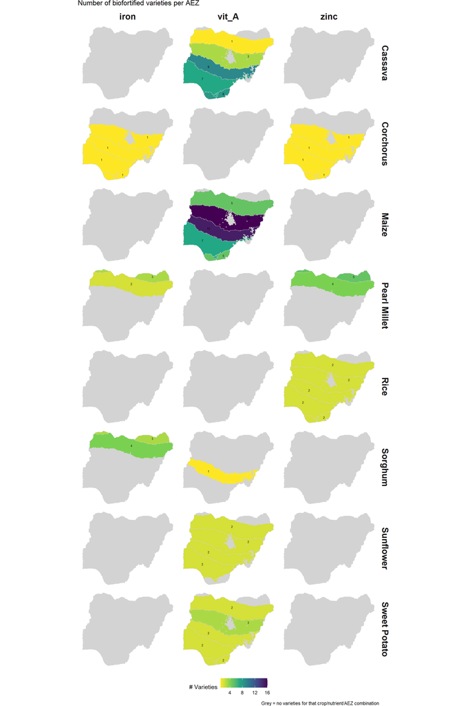

Figure 2: Number of Biofortified Varieties per AEZ

```r
# Join counts to spatial data
vect_aez_geo_joined <- vect_aez_geo |>
  mutate(AEZ = as.character(AEZ)) |>
  left_join(df_nsp_biofort_counts, by = "AEZ", relationship = "many-to-many")

vect_aez_geo_joined <- vect_aez_geo_joined |>
  filter(!is.na(micronutrient))|>
  filter(!is.na(Crop.Name))


# # create a separate spatvector for the labels just for visualisation

# rec_id    = column identifying a record (constant across all its polygons)
# label_var = the number to display
# facet_row / facet_col = your facet_grid variables
grp <- c("AEZ", "n_varieties", "Crop.Name", "micronutrient")

# 1. Merge all rows/polygons belonging to the same record within each facet
vect_agg <- aggregate(vect_aez_geo_joined, by = grp)

# 2. Split into contiguous parts and keep the largest per record per facet
vect_parts <- disagg(vect_agg)
vect_parts$area <- expanse(vect_parts)
vect_parts <- vect_parts[order(vect_parts$area, decreasing = TRUE), ]
vect_parts <- vect_parts[!duplicated(as.data.frame(vect_parts)[, c("AEZ", "Crop.Name", "micronutrient")]), ]

# 3. One point per record, guaranteed inside its polygon
vect_pts <- centroids(vect_parts, inside = TRUE)



# Plot: one facet per Crop x Micronutrient combination
ggplot(vect_aez_geo_joined) +
  geom_spatvector(
    data = vect_aez_geo,
    fill = "lightgrey",
    color = "lightgrey",
    linewidth = 0.2
  ) +
  geom_spatvector(
    aes(fill = n_varieties),
    color = "lightgrey",
    linewidth = 0.2
  ) +
  scale_fill_viridis_c(
    option = "blues",
    na.value = "lightgrey",
    name = "# Varieties",
    direction = -1
  ) +
  geom_spatvector_text(
    data = vect_pts,
    aes(label = n_varieties),
    color = "black",
    size = 2
  ) +
  facet_grid(Crop.Name ~ micronutrient, drop = TRUE) +
  labs(
    title = "Number of biofortified varieties per AEZ",
    caption = "Grey = no varieties for that crop/nutrient/AEZ combination"
  ) +
  theme_minimal() +
  theme(
    axis.text = element_blank(),
    axis.ticks = element_blank(),
    axis.title = element_blank(),
    panel.grid = element_blank(),
    strip.text = element_text(face = "bold", size = 16),
    legend.position = "bottom",
    panel.spacing = unit(0.1, "lines"),
    plot.margin = margin(0, 0, 0, 0, "cm")
  )
```

# Visualising the spatial product catalogue for Nigeria

There are two options we are considering for a pilot spatial visualisation of the biofortified variety catalogue for Nigeria:

1. a Shiny interface with a client application and backendserver
2. a standalone html file with embedded interactive maps

When deciding whether to embed a Leaflet map in a standalone HTML file or within an R Shiny application, the best choice depends on whether our map needs to communicate with a server.

**Standalone HTML Map** A standalone HTML map (created via R’s htmlwidgets, leaflet export, or pure JavaScript) is completely static on the backend but interactive on the frontend and has these attributes:

- No Hosting Costs: We do not need an active server (like ShinyServer or shinyapps.io). We can host it for free on GitHub Pages, Netlify, or AWS S3.
- Fast Performance: Because there is no server-side computation, the map loads quickly for the user, limited only by their internet speed and data size.
- Scalability: Many users can view the map at the same time without crashing a server, as all rendering happens directly in the user’s web browser.
- Easy Sharing: We can email the map as a single .html file attachment, and it will open and work completely offline.

**R Shiny Application Map** An R Shiny map connects our Leaflet frontend to a live R session running on a backend server.

- Dynamic Data Updates: The map can query a live SQL database, fetch real-time APIs, or react to user-uploaded files on the fly.
- Bidirectional Communication: We can capture user actions on the map (like clicking a marker or drawing a bounding box) and use those actions to trigger complex R scripts, run statistical models, or update separate charts.
- Heavy-Duty Data Processing: Shiny can process, filter, and summarise gigabytes of spatial data, the data are on the server, sending only the tiny, necessary pieces to the browser.
- Secured Access: Because the data processing happens on the server, we can hide sensitive underlying datasets or restrict app access behind user authentication.

Because our database is small, we can easily build this using either approach, and our choice depends on how we want to deploy it. Since our dataset is small, a standalone HTML file can hold all the data and handle filtering entirely inside the user’s browser. However, if we want to write standard R code for filtering or plan to expand the app later, then Shiny remains an option. As a result we will build prototype applications using both approaches.

The prototypes should have the following functionality:

- allow the user to choose a crop and or a micronutrient using a dropdown text filter.
- display the results of this selection (similar to the individual maps in Figure 2) in an interactive map
- allow the user to select a specific Agro Ecological Zone on the map
- display the varieties for the selected crop * micronutrient * AEZ combination
- when the user clicks on the variety in the table display further details of the variety including an image if available

The data required are:

1. A long table with a row for each variety * agro-ecological zone combination with an identification for the variety
2. A table of the details of the biofortified varieties with a unique identification with one row per variety, including characteristics, a link to HarvestPlus attributes and a reference to an image file if available

The merged database of NSP and HarvestPlus only contains a subset of the biofortified varieties that are in the NSP database and for which there are data on the geographical unit for which the variety is adapted.

We therefore need to reintroduce the varieties that were not matched.

```r
# rejoin the non-merged data from NSP add a preference code to show that merged rows are preferred the remove the non-preferred when there are duplicates

# we start with 51 varieties in df_nsp_biofort and 29 in the df_merge_manual, we expect 51 varieties of which 29 should have hp data

# Bind and resolve duplicates by dataset preference
df_nsp_biofort_merged_hp <- bind_rows(
  df_merge_manual |> mutate(pref = 1),
  df_nsp_biofort |> mutate(pref = 2)
) |>
  arrange(pref) |>                  # Puts source 1 (preferred) on top
  distinct(nsp_variety_id, .keep_all = TRUE) |>  # Keeps the first 'id' it sees
  select(-pref)

# this produces 51 varieties with 29 containing hp data

# save this for use in the Shiny app
# should have these columns: variety_id | variety_name | crop | micronutrient | unit_id



## COMMENTED OUT BECAUSE IMAGES ADDED AFTERWARDS MANUALLY
##---------------------------------------------------------

# df_nsp_biofort_merged_hp |>
#   rename(
#     variety_id = nsp_variety_id,
#   ) |>
#   select(variety_id, Variety.Name,  Crop.Name,  oc, zinc_content, iron_content, vitA_content, Micronutrient_concentratio, agro ) |>
#   write.csv("E:/repos/Nigeria_Biofortification_Atlas/variety_details.csv", row.names = F)
```

What the user can do with the prototype applications:

- Selectors: Crop and micronutrients can be selected via dropdowns above the map.
- Map: Showing the AEZ polygons and using a variable colour scale with some transparency, with grey for zero-count units and a legend. Hovering shows the AEZ name and the number of varieties.
- Click a polygon: It gets a red outline and the table filters to that AEZ Click it again, or use “Clear selection”, to go back to all AEZs
- Table: Sortable by clicking the headers, plus a search box.
- Row click: Shows the image (if available), then the details list, with any http(s) values turned into links (for our image-source link).

## Prototype standalone html spatial product catalogue using leaflet

A leaflet map can be embedded within a standalone html file which can be distributed to users. For instance the leaflet map below (Figure 3) shows the number of biofortified cassava varieties in Nigeria.

```r
# convert to sf until leaflet properly accepts spatvector
sf_aez_geo_joined <- st_as_sf(vect_aez_geo_joined) |> filter(Crop.Name == "Cassava", micronutrient == "vit_A") |> # leaflet needs WGS84
  group_by(AEZ) |>
  summarise(AEZ_name = first(AEZ_name), n_varieties = first(n_varieties), .groups = "drop") |> # one row per unit_id
  st_make_valid()

leaflet(sf_aez_geo_joined, width = "100%") %>%
  addProviderTiles(providers$OpenStreetMap.HOT, group = "OSM (HOT)") %>%
  addPolygons(
    label = ~ stringr::str_c('Varieties =', n_varieties),
    labelOptions = labelOptions(direction = 'auto'),
    color = "#03F",
    weight = 1,
    opacity = 0.5,
    fill = T,
    #fillColor = ~ pal(FAO_limit),
    fillOpacity = 0.2,
    dashArray = NULL,
    smoothFactor = 1,
    noClip = FALSE,
    popup = paste(
      '# Varieties  =',
      sf_aez_geo_joined$n_varieties
    ),
    popupOptions = NULL,
    highlightOptions = NULL,
  )
```

[interactive chart not shown]

Figure 3: Number of Biofortified Cassava Varieties per AEZ

It is possible to fulfill our required functionality with a standalone html file using leaflet and a range of R packages.

The crosstalk package, for instance, links widgets in the browser, `filter_select()` can be used for dropdowns for crop and micronutrient, while a leaflet map and a DT table can all share one filtered dataset. It’s saved with `htmlwidgets::saveWidget(..., selfcontained = TRUE)` or put in an R Markdown/Quarto page, and it runs anywhere. Crosstalk has some shortcomings, however. Crosstalk filters rows, but it doesn’t aggregate them to show the number of varieties per AEZ. Our map colours each polygon by the number of distinct varieties, and that number changes as the filters change. Crosstalk can show or hide polygons, but it can’t recolour them by a recomputed count. Leaflet’s crosstalk support is mainly for filtering, so clicking a polygon to filter the table is not reliable.

An alternative is leaflet plus custom JavaScript. We still build it from R, pre-compute the variety counts for every AEZ * crop * micronutrient combination, embed those plus the details table and base64 images as JSON, and use `htmlwidgets::onRender()` to add the dropdowns, recolour the polygons, handle the click, and fill the table and details panel. This works fully offline (apart from the map background tile) and can be hosted anywhere static, such as GitHub Pages.

A script was written in R to create the html file, R writes the varieties, AEZ names, variety details and base64-encoded images into the page as JSON, and a block of plain JavaScript does the counting, colouring and table updates in the browser. The polygons come from R’s leaflet package, and the script finds each one by its unit_id so it can recolour it. A duplicate-unit_id clean-up is included. It uses the inputs created above: varieties.csv, variety_details.csv, and images/, as well as a geopackage for the spatial data - units.gpkg.

The final html page can be accessed here:

https://geagrofia.github.io/Nigeria_Biofortification_Atlas/nigeria%20biofort%20crop%20catalogue.html

## Prototype Shiny interface spatial product catalogue

Shiny is an extension of R scripts to allow the production of user interfaces. Shiny is commonly used to produce dashboards, but can be combined with leaflet to display spatial data and permit a user to select units on the map and view other information. Shiny offers us a way of selecting a particular geographic unit to filter our database of biofortified crop varieties.

The shiny interface can be accessed here:

https://geagrofia.shinyapps.io/Nigerian_Biofortified_Crops_Catalogue/

This loads a little more slowly than the html page, the design is more like a dashboard, rather than horizontal blocks in the html page.

## References

Akinwumiju, A. S., A. A. Adelodun, and O. I. Orimoogunje. 2020. “Agro-Climato-Edaphic Zonation of Nigeria for a Cassava Cultivar Using GIS-Based Analysis of Data from 1961 to 2017.” *Sci Rep* 10 (1): 1259. https://doi.org/10.1038/s41598-020-58280-4.

Lung’aho, Mercy. 2025. *Framework for Embedding Nutrition into Breeding Pipelines and Processes: Guidance Note*. IITA.

Nigerian Seed Portal Initiative. 2026. *Nigerian Seed Portal Initiative*. Https://www.seedportal.org.ng/.

Reuter, H. I., A. Nelson, and A. Jarvis. 2007. “An Evaluation of Void-Filling Interpolation Methods for SRTM Data.” *International Journal of Geographical Information Science* 21 (9): 983–1008. https://doi.org/10.1080/13658810601169899.